# Efficient & Parallel Programming in R

Salt Lake City R Users Group, February 27, 2020

## Motivation ($$$)

## Efficiency & why we care?

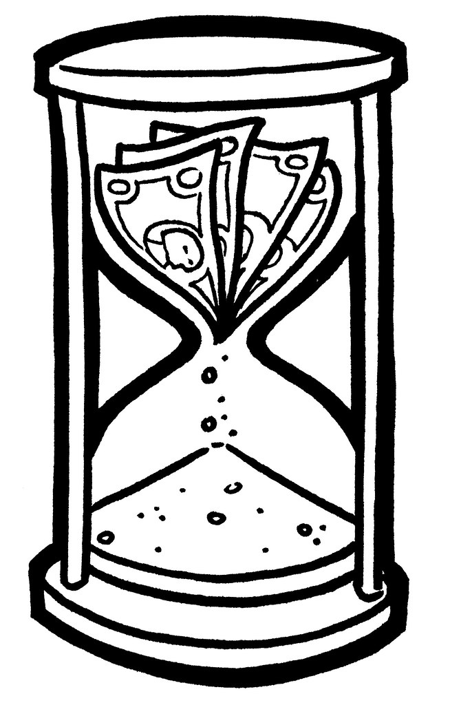

- Time is money

## Efficiency & why we care?

[figure not shown]

- Time is money
- Do more with less

## Programmer Time vs Computer Time.

- `Cost(Time(Programmer))` >>`Cost(Time(Computer))`

[figure not shown]

## Programmer Time vs Computer Time

- `Cost(Time(Programmer))` >>`Cost(Time(Computer))`
- `Cost(Programmer)` >>`Cost(Computer)`

## Efficient Project Workflow

## Top Tips

1. Start with the end in mind.
2. Make a plan
3. Pick your tools carefully.
4. Document you work.
5. Make your work reproducible.

Adapted from *Efficient R Programming*, C Gillespie and R Lovelace, 2016, Chapter 4.

## Start with the end in mind

[figure not shown]

- Keep objectives in the front of your mind.
  - Publication
  - Methods
  - Package development
  - Reproducible workflow vs. One off.
- We left tangents behind in Geometry, don’t follow them now

## Make a plan

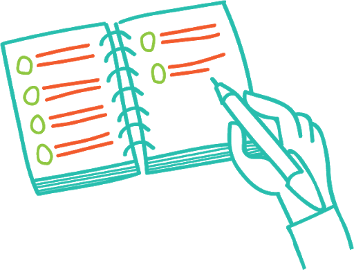

- Statistical Analysis Plan
- Statement of scope
- Diagrams
  - UML Class
  - Process flow
  - swim lanes

## Pick your tools

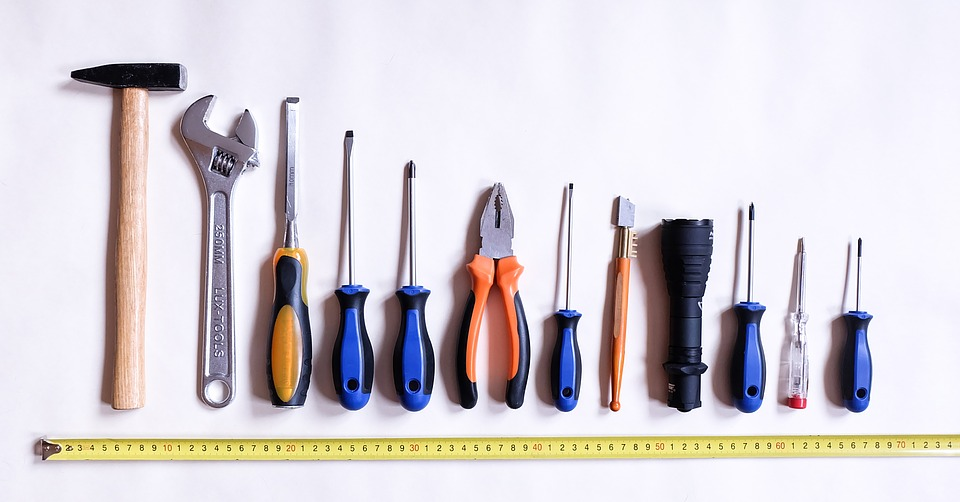

- R is not always the right tool
- Python is sometimes right
- SAS even even has advantages at times

## Pick your tools

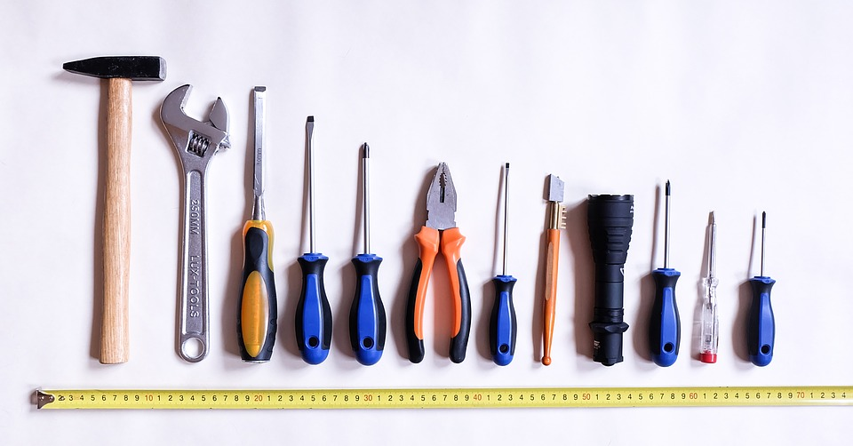

- R is not always the right tool
- Python is sometimes right
- SAS even even has advantages at times

In all seriousness; Tools:

- Which Packages
- Write & Compile code
- MCMC, BUGS, Bootstrapping, or Simulation?

## Document your work

- If you can’t understand it neither will anyone else.
- `Programmer time >> Computer time`

[figure not shown]

## Document your work

- If you can’t understand it neither will anyone else.
- `Programmer time >> Computer time`

> If ever faced with the choice between code you can understand and code that is fast choose code you can understand.

## Efficient Programming

## Myth

> Efficient code is Verbose.

## Truth

> Every new line of code you willingly bring into the world is code that has to be debugged, code that has to be read and understood, code that has to be supported. Every time you write new code, you should do so reluctantly, under duress, because you completely exhausted all your other options.

## R’s Cardinal Sin

[figure not shown]

- Never, Never, Never grow vectors.

## Example

```r
system.time({
  x <- logical(0)
  i <- 1L
  while (i <= 10000000){
      x[[i]] <- rnorm(1) > 0
      i <- i + 1L
  }
})
```

```
##    user  system elapsed
##   47.42    0.97   51.80
```

- At each iteration x grows in length by 1, ie.
  - Check if there is space for another number
  - if not, create a new vector that has space (a reallocation)
- There are thousands is not millions of reallocations in this call.

## Solution: Vectorize

```r
system.time({
  x <- rnorm(10000000) > 0
})
```

```
##    user  system elapsed
##    1.46    0.03    1.50
```

- Let R figure out the best way to allocate
- Think in vectors & lists
- Get to compiled code as quickly as possible.

## Tool: Mapping

[figure not shown]

## Mapping (thinking in vectors)

[figure not shown]

- Apply the same function/operation/etc to _________
  - Element of a List/Vector
  - Subset of data.
  - Each set of parameters.

## Mapping Example Demographics

- *For each* Diagnosis, compute:
  - Total number of patients
  - Age at time of Diagnosis
  - Sex breakdown
  - Racial breakdown
  - Total amount of antibiotics
  - Number of unique antibiotics
  - Etcetera.

## Mapping Example Simulation

- Create a list of parameters you are interested in.
- **For each** set of parameters generate a data set then
  - fit a model to the data,
  - compute summary statistics for fit,
  - generate plots for
    - Goodness of fit
    - outliers
    - Etcetera.
- Compare the summary statistics across sets of parameters.

## Tool: Parallel Programming

[figure not shown]

## What is parallel programming

[figure not shown]

Modern Computers have processor that can do many things independently at the same time. This computer can do

```r
parallel::detectCores()
```

```
## [1] 8
```

things things at the same time. This is one way there are other things running on the machine at the same time, such as windows, chrome, this presentation etc.

Parallel programming is telling 1 program to do multiple things at once.

## Simplest Parallel Programming: Running in the background

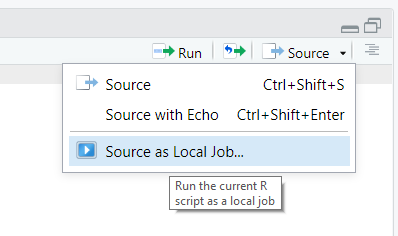

- Run on local machine
- Keep doing other things
- Progress shown in Rstudio.

## Running in the background

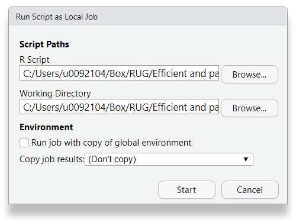

- Results can be copied back to your environment.

## Simulation Example

We will use the `Simulation_Setup.R` and `simulation1.R` files to run a simulation the effects of estimating effects post variable selection.

[figure not shown]

## Running

```r
beta  <- sample(c(rep(c(-1,1),each=5),c(rep(0,40))))
Sigma <- .8**abs(outer(seq_along(beta), seq_along(beta), `-`))
```

```r
system.time({
    simulate_one( 250, beta, Sigma
                , analyze=analyze_with_enet
                )
})
```

```
##    user  system elapsed
##    0.56    0.06    0.62
```

## Running All

```r
system.time({
    results <- run_simulation( m=100, n=250
                             , beta=beta, Sigma=Sigma
                             , analyze=analyze_with_enet)
})
```

```
##    user  system elapsed
##   40.37    0.25   43.08
```

## Running `simulation1.R` in batch

*100* replications isn’t bad but I want more like **1,000**.

However,

- If you run without saving anything nothing changes.
- Running with a ‘copy job results’ option will bring results back.
- But…

## Explicit Saving

### Single objects

```r
file <- format(now(), "results %Y%m%d-%H%M%S.rds")
```

#### Saving

```r
saveRDS(results, file)
# OR (fast write, but larger file)
writeRDS(results, file)
```

#### Reading

```r
# Read back to specific object
# & save to object
results <- readRDS(file)
```

### With bindings (i.e. variable names)

```r
file <- format(now(), "results %Y%m%d-%H%M%S.RData")
```

```r
save.image(file)         #< Everything
save(results, file=file) #< Selectively
```

```r
load(file)               #< Global Env
load(file, results.env)  #< Specific Env
```

## MORE!

### Problem

That was one parameter set.

### Solution

Run lots of batchs

### But

We don’t want to create a file for each set of parameters

## Altering batch processes

Batch scripting may be altered by passing command line arguments (though not easily through RStudio)

#### Linux

```bash
R CMD BATCH simulation1.R --args 1
```

#### Windows

```bash
Rterm BATCH simulation1.R --args 1
```

### Output

```
> commandArgs()
[1] "C:\\Program Files\\R\\R-3.6.2\\bin\\x64\\rterm.exe"
[2] "-f"
[3] "commandArgs.R"
[4] "--args"
[5] "1"
> commandArgs(TRUE)
[1] "1"
```

## Spawn multiple jobs

#### Linux

```bash
Rscript simulation2.R 1 &
Rscript simulation2.R 2 &
Rscript simulation2.R 3 &
Rscript simulation2.R 4 &
```

#### Windows

is “complicated”

### Note

This is relevant to know for CHPC.

## Timing for four

```r
start <- proc.time()
withr::with_dir("Simulation 2/", {
    system2(Sys.which("Rscript"), "simulation2-setup.R", wait=TRUE)
    system2(Sys.which("Rscript"), c("simulation2.R", "1"), "1.out", "1.err" , wait=FALSE)
    system2(Sys.which("Rscript"), c("simulation2.R", "2"), "2.out", "2.err" , wait=FALSE)
    system2(Sys.which("Rscript"), c("simulation2.R", "3"), "3.out", "3.err" , wait=FALSE)
    system2(Sys.which("Rscript"), c("simulation2.R", "4"), "4.out", "4.err" , wait=FALSE)
})
# Wait for files.
expected <- glue("Simulation 2/results-{1:4}.rds")
while (any(!file.exists(expected))) Sys.sleep(0.001)
proc.time()-start
```

```
##    user  system elapsed
##    1.43    6.94   58.30
```

## Going Parallel

## Going Parallel

- We’ve gone paralell in a cludgy sort of way.
- we want something elegant.

There are two main paths

#### foreach

- Straight forward
- Explicit
- More changes to code
- Older

#### future

- Uses parallelized ‘promises’
- Implicit
- Code looks more similar to serialized code
- New interface

## `foreach` paradigm

### Setup

- We need a set of workers (cluster)
  - processes that can handle the computations.
- Special functions handle delegating computations to the group.
- The main package is foreach

## Clusters

- doParallel - Interfaces a cluster communicating over sockets.
- [doMC](https://cran.r-project.org/package=doSNOW) - Interfaces a cluster utilizing multiple cores of a single processor.
- doSNOW - Interfaces a ‘snow’ cluster, simple network of workstations.
- doMPI - Cluster communicating over message passing interface (MPI). Typical in High performance computing clusters but is overkill for most statistics applications. *Requires extensive out of R configuration of the cluster.*

## Steps to parallel

### Create Cluster

```r
cl <- parallel::makeCluster(4)
doParallel::registerDoParallel(cl)
```

### Evaluate in parallel

```r
library(foreach)
parameters <- readRDS('Simulation 2/parameters.rds') %>%
    select(m,n,beta,Sigma) %>%
    pmap(list)
system.time(try({
parallel.results <-
    foreach(parm=parameters) %dopar%{
        do.call(run_simulation, parm)
    }

}))
```

```
## Error in { : task 1 failed - "could not find function "rerun""
```

```
##    user  system elapsed
##    0.03    0.00    0.13
```

## What happened.

The previous call failed because:

1. There are 4 separate instances of R running.
2. Each maintains a separate workspace.
3. Packages must be loaded on each worker

## Fixed

```r
system.time(try({
parallel.results <-
    foreach( parm=parameters
           , .packages=c('tidyverse', 'assertthat', 'elasticnet')
           ) %dopar%{
        do.call(run_simulation, c(parm,list(analyze=analyze_with_enet)))
    }

}))
```

```
##    user  system elapsed
##    0.11    0.01   49.92
```

## Future approach

parallelism is achieved through registering a plan or strategies.

- sequential (default)
- transparent - essentially the same as sequential
- multisession - multiple R sessions on host computer
- multicore - forked R Processes, not available on Windows.
- multiprocess - shortcut for multicore if available, otherwise multisession.
- cluster - Heterogeneous cluster of machines
- remote - Simply run on remote session.

## Example

```r
library(furrr)
plan(multiprocess)
system.time({
results <- readRDS("Simulation 2/parameters.rds") %>%
    select(m,n,beta, Sigma) %>%
    future_pmap(run_simulation, analyze=analyze_with_enet
               , .options = future_options( globals = my.functions
                                          , packages=c('tidyverse', 'elasticnet', 'assertthat')) )
})
```

```
##    user  system elapsed
##    0.23    0.02   50.50
```